# Genomic SEM substance use - plots of rg with other traits

## By EFA factor - adjusted

We repeat the model but now using summary statistics adjusted for index-event bias.

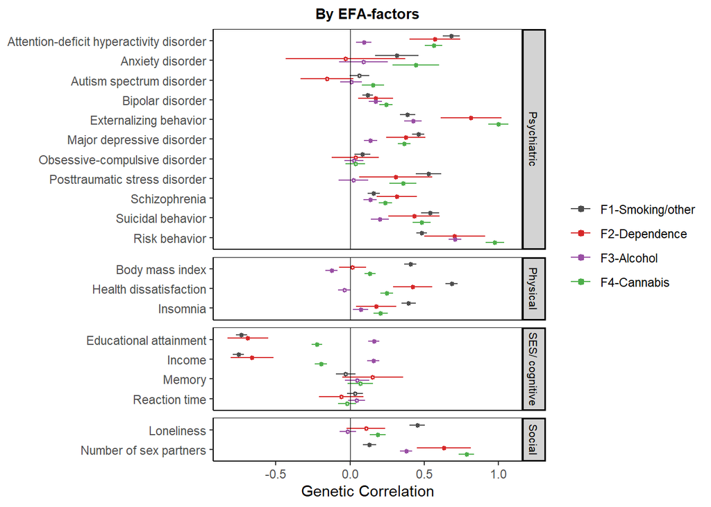

```r
F1 <- readRDS("results/factor_rg/rg_f1_adj.RDS")
F2 <- readRDS("results/factor_rg/rg_f2_adjusted.RDS")
F3 <- readRDS("results/factor_rg/rg_f3_adjusted.RDS")
F4 <- readRDS("results/factor_rg/rg_f4_adjusted.RDS")

labels <- fread("scripts/labels.csv")

res <- rbind(F1, F2, F3, F4)

# Combine and add the labels

res <- res %>%
  mutate(p_value = ifelse(p_value == "< 5e-300", 5e-300, p_value)) %>%
  mutate(p_value = as.numeric(p_value)) %>%
  full_join(labels, by = c("rhs" = "short")) %>%
  mutate(Category = fct_relevel(Category, "Psychiatric", "Physical", "SES/ cognitive", "Social")) %>%
  select(lhs, label, STD_Genotype, STD_Genotype_SE, p_value, Category) %>%
  rename(rg = STD_Genotype, SE = STD_Genotype_SE) %>%
  mutate(lhs = recode(lhs, "F1" = "F1-Smoking/other", "F2" = "F2-Dependence", "F3" = "F3-Alcohol", "F4" = "F4-Cannabis")) %>%
  mutate(lhs = as_factor(lhs))

# Correct for multiple testing

res <- res %>%
  group_by(lhs) %>%
  mutate(p_fdr = p.adjust(as.numeric(p_value), "BH")) %>%
  ungroup() %>%
  mutate(p_fdr_bin = ifelse(p_fdr < 0.05, "sig", "nonsig")) %>%
  mutate(p_fdr_bin = as_factor(p_fdr_bin))

# Order by correlation with G

res <- res %>%
  mutate(rg_F1 = ifelse(lhs == "F1-General/smok", rg, NA)) %>%
  arrange(desc(rg_F1)) %>%
  mutate(label = factor(label, levels = unique(label)))

# Save ordering for the other plots
order <- as_tibble(res$label)

# Plot

plt_efa <- ggplot(res, aes(x = rg, y = fct_rev(label), color = lhs, shape = p_fdr_bin, fill = p_fdr_bin)) +
  geom_pointrange(aes(xmin = rg - 1.96 * as.numeric(SE), xmax = rg + 1.96 * as.numeric(SE)),
                  position = position_dodge(width = -0.65),
                  size = 0.3, fatten = 2) +
  facet_grid(Category ~ ., scales = "free", space = "free_y") +
  geom_vline(xintercept = 0, size = 0.15) +
  theme(axis.title.y = element_blank()) +
  theme_classic() +
  theme(axis.title.y = element_blank(),
        strip.text = element_text(colour = 'black', size = 8),
        strip.background = element_rect(fill = "lightgrey", color = "black"),
        panel.border = element_rect(color = "black", fill = NA),
        plot.title = element_text(size = 10, face = "bold", hjust = 0.5)
  ) +
  scale_colour_manual(values = c("grey30", "#D62728", "#984EA3", "#4DAF4A"), name = NULL) +
  scale_shape_manual(values = c(19, 21)) +
  scale_fill_manual(values = c(NA, "white")) +
  xlab("Genetic Correlation") +
  guides(shape = "none", fill = "none") +
  ggtitle("By EFA-factors")

plt_efa
```

```r
ggsave("results/factor_rg/rg_efa_adj.svg", plt_efa, width = 7, height = 9)

plt_efa_b <- plt_efa + ggtitle("")
ggsave("results/factor_rg/rg_efa_adj.png", plt_efa_b, width = 7, height = 7, dpi=600)
fwrite(res, "results/factor_rg/factor_rg_EFA_adj.csv")
```

## By substance

Next, we compare the correlations for G and specific substance factors.

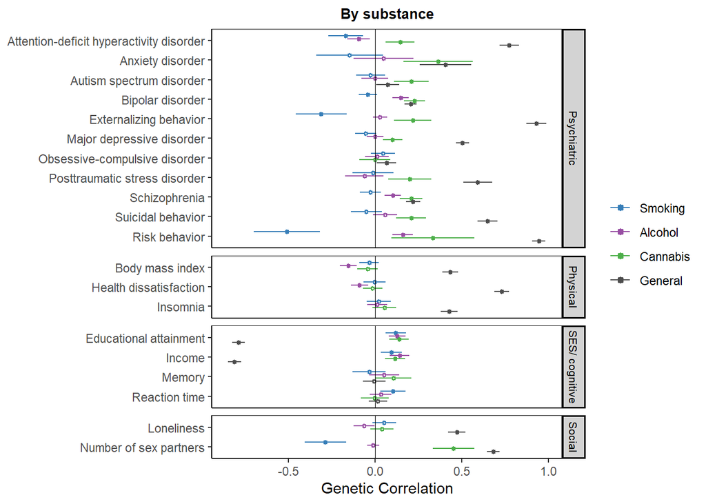

```r
SMK <- readRDS("results/factor_rg/rg_smk.RDS") %>%
  filter(lhs != "G")
ALC <- readRDS("results/factor_rg/rg_alc.RDS") %>%
  filter(lhs != "G")
CAN <- readRDS("results/factor_rg/rg_can.RDS") %>%
  filter(lhs != "G")
G <- readRDS("results/factor_rg/rg_gbysub.RDS")

res <- rbind(SMK, ALC, CAN, G)

# Combine and add the labels

res <- res %>%
  mutate(p_value = ifelse(p_value == "< 5e-300", 5e-300, p_value)) %>%
  mutate(p_value = as.numeric(p_value)) %>%
  full_join(labels, by = c("rhs" = "short")) %>%
  mutate(Category = fct_relevel(Category, "Psychiatric", "Physical", "SES/ cognitive", "Social"))

# To add difference scores, pivot the table to wide format and back

res <- res %>%
  select(lhs, label, STD_Genotype, STD_Genotype_SE, p_value, Category) %>%
  rename(rg = STD_Genotype, SE = STD_Genotype_SE) %>%
  mutate(lhs = fct_relevel(lhs, "SMK", "ALC", "CAN", "G")) %>%
  mutate(lhs = recode(lhs, "SMK" = "Smoking", "ALC" = "Alcohol", "CAN" = "Cannabis", "G" = "General"))

# Correct for multiple testing

res <- res %>%
  mutate(p_bin = ifelse((rg < 0 & rg + 1.96 * as.numeric(SE) < 0) | (rg > 0 & rg - 1.96 * as.numeric(SE) > 0) , "*", "")) %>%
  group_by(lhs) %>%
  mutate(p_fdr = p.adjust(as.numeric(p_value), "BH")) %>%
  ungroup() %>%
  mutate(p_fdr_bin = ifelse(p_fdr < 0.05, "sig", "nonsig")) %>%
  mutate(p_fdr_bin = as_factor(p_fdr_bin))

# Order same as EFA plot

order <- order %>% distinct()
res$label <- factor(res$label, levels = order$value)

# Plot

plt_sub <- ggplot(res, aes(x = rg, y = fct_rev(label), color = lhs, shape = p_fdr_bin, fill = p_fdr_bin)) +
  geom_pointrange(aes(xmin = rg - 1.96 * as.numeric(SE), xmax = rg + 1.96 * as.numeric(SE)),
                  position = position_dodge(width = -0.65),
                  size = 0.3, fatten = 2) +
  facet_grid(Category ~ ., scales = "free", space = "free_y") +
  geom_vline(xintercept = 0, size = 0.15) +
  theme(axis.title.y = element_blank()) +
  theme_classic() +
  theme(axis.title.y = element_blank(),
        strip.text = element_text(colour = 'black', size = 8),
        strip.background = element_rect(fill = "lightgrey", color = "black"),
        panel.border = element_rect(color = "black", fill = NA),
        plot.title = element_text(size = 10, face = "bold", hjust = 0.5)
  ) +
  scale_colour_manual(values = c("#377EB8", "#984EA3", "#4DAF4A", "grey30"), name = NULL) +
  scale_shape_manual(values = c(19, 21)) +
  scale_fill_manual(values = c(NA, "white")) +
  xlab("Genetic Correlation") +
  guides(shape = "none", fill = "none") +
  ggtitle("By substance")

plt_sub
```

```r
ggsave("results/factor_rg/rg_sub.svg", plt_sub, width = 7, height = 9)
ggsave("results/factor_rg/rg_sub.png", plt_sub, width = 7, height = 9, dpi=600)
fwrite(res, "results/factor_rg/factor_rg_sub.csv")
```

## By trait type - unadjusted

We compare the genetic correlation between the external traits and the type of behavior factors versus the correlation with the general factor.

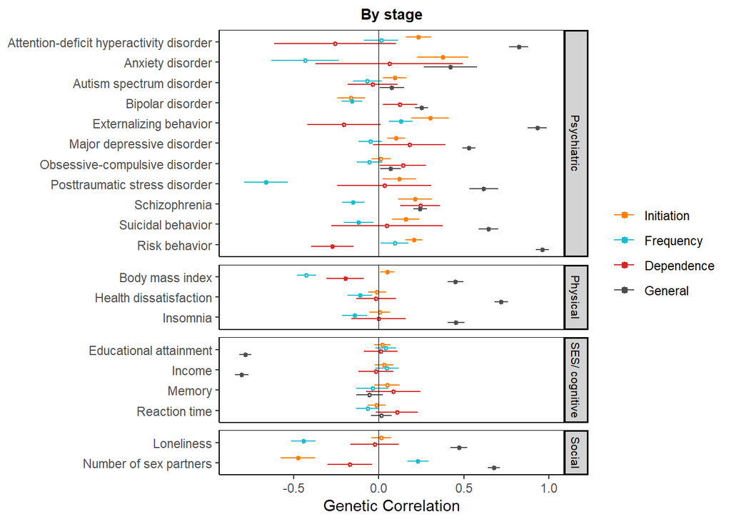

```r
INI <- readRDS("results/factor_rg/rg_ini.RDS") %>%
  filter(lhs != "G")
FRQ <- readRDS("results/factor_rg/rg_frq.RDS") %>%
  filter(lhs != "G")
DEP <- readRDS("results/factor_rg/rg_dep.RDS") %>%
  filter(lhs != "G")
G <- readRDS("results/factor_rg/rg_gbytrait.RDS")

res <- rbind(INI, FRQ, DEP, G)

# Combine and add the labels

labels <- fread("scripts/labels.csv")

res <- res %>%
  mutate(p_value = ifelse(p_value == "< 5e-300", 5e-300, p_value)) %>%
  mutate(p_value = as.numeric(p_value)) %>%
  full_join(labels, by = c("rhs" = "short")) %>%
  mutate(Category = fct_relevel(Category, "Psychiatric", "Physical", "SES/ cognitive", "Social"))

# To add difference scores, pivot the table to wide format and back

res <- res %>%
  select(lhs, label, STD_Genotype, STD_Genotype_SE, p_value, Category) %>%
  rename(rg = STD_Genotype, SE = STD_Genotype_SE) %>%
  mutate(lhs = fct_relevel(lhs, "INI", "FRQ", "DEP", "G")) %>%
  mutate(lhs = recode(lhs, "INI" = "Initiation", "FRQ" = "Frequency", "DEP" = "Dependence", "G" = "General"))

# Correct for multiple testing

res <- res %>%
  mutate(p_bin = ifelse((rg < 0 & rg + 1.96 * as.numeric(SE) < 0) | (rg > 0 & rg - 1.96 * as.numeric(SE) > 0) , "*", "")) %>%
  group_by(lhs) %>%
  mutate(p_fdr = p.adjust(as.numeric(p_value), "BH")) %>%
  ungroup() %>%
  mutate(p_fdr_bin = ifelse(p_fdr < 0.05, "sig", "nonsig")) %>%
  mutate(p_fdr_bin = as_factor(p_fdr_bin))

# Order same as EFA plot

res$label <- factor(res$label, levels = head(order$value, n=20))

# Plot

plt_trait <- ggplot(res, aes(x = rg, y = fct_rev(label), color = lhs, shape = p_fdr_bin, fill = p_fdr_bin)) +
  geom_pointrange(aes(xmin = rg - 1.96 * as.numeric(SE), xmax = rg + 1.96 * as.numeric(SE)),
                  position = position_dodge(width = -0.65),
                  size = 0.3, fatten = 2) +
  facet_grid(Category ~ ., scales = "free", space = "free_y") +
  geom_vline(xintercept = 0, size = 0.15) +
  theme(axis.title.y = element_blank()) +
  theme_classic() +
  theme(axis.title.y = element_blank(),
        strip.text = element_text(colour = 'black', size = 8),
        strip.background = element_rect(fill = "lightgrey", color = "black"),
        panel.border = element_rect(color = "black", fill = NA),
        plot.title = element_text(size = 10, face = "bold", hjust = 0.5)
  ) +
  scale_colour_manual(values = c("#FF7F00", "#17BECF", "#D62728", "grey30"), name = NULL) +
  scale_shape_manual(values = c(19, 21)) +
  scale_fill_manual(values = c(NA, "white")) +
  xlab("Genetic Correlation") +
  guides(shape = "none", fill = "none") +
  ggtitle("By stage")

plt_trait
```

```r
ggsave("results/factor_rg/rg_trait_unadjusted.svg", plt_trait, width = 7, height = 9)
ggsave("results/factor_rg/rg_trait_unadjusted.png", plt_trait, width = 7, height = 9)
fwrite(res, "results/factor_rg/factor_rg_trait_unadjusted.csv")
```

## By trait type - index event bias adjusted

We compare the genetic correlation between the external traits and the type of behavior factors versus the correlation with the general factor.

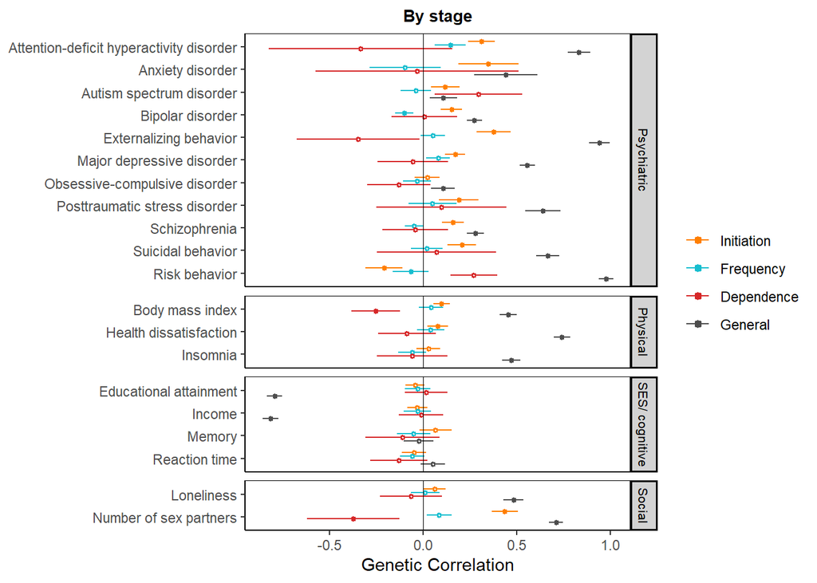

```r
INI <- readRDS("results/factor_rg/rg_adjusted_ini.RDS") %>%
  filter(lhs != "G")
FRQ <- readRDS("results/factor_rg/rg_adjusted_frq.RDS") %>%
  filter(lhs != "G")
DEP <- readRDS("results/factor_rg/rg_adjusted_dep.RDS") %>%
  filter(lhs != "G")
G <- readRDS("results/factor_rg/rg_adjusted_gbytrait.RDS")

res <- rbind(INI, FRQ, DEP, G)

# Combine and add the labels

labels <- fread("scripts/labels.csv")

res <- res %>%
  mutate(p_value = ifelse(p_value == "< 5e-300", 5e-300, p_value)) %>%
  mutate(p_value = as.numeric(p_value)) %>%
  full_join(labels, by = c("rhs" = "short")) %>%
  mutate(Category = fct_relevel(Category, "Psychiatric", "Physical", "SES/ cognitive", "Social"))

# To add difference scores, pivot the table to wide format and back

res <- res %>%
  select(lhs, label, STD_Genotype, STD_Genotype_SE, p_value, Category) %>%
  rename(rg = STD_Genotype, SE = STD_Genotype_SE) %>%
  mutate(lhs = fct_relevel(lhs, "INI", "FRQ", "DEP", "G")) %>%
  mutate(lhs = recode(lhs, "INI" = "Initiation", "FRQ" = "Frequency", "DEP" = "Dependence", "G" = "General"))

# Correct for multiple testing

res <- res %>%
  mutate(p_bin = ifelse((rg < 0 & rg + 1.96 * as.numeric(SE) < 0) | (rg > 0 & rg - 1.96 * as.numeric(SE) > 0) , "*", "")) %>%
  group_by(lhs) %>%
  mutate(p_fdr = p.adjust(as.numeric(p_value), "BH")) %>%
  ungroup() %>%
  mutate(p_fdr_bin = ifelse(p_fdr < 0.05, "sig", "nonsig")) %>%
  mutate(p_fdr_bin = as_factor(p_fdr_bin))

# Order same as EFA plot

res$label <- factor(res$label, levels = head(order$value, n=20))

# Plot

plt_trait <- ggplot(res, aes(x = rg, y = fct_rev(label), color = lhs, shape = p_fdr_bin, fill = p_fdr_bin)) +
  geom_pointrange(aes(xmin = rg - 1.96 * as.numeric(SE), xmax = rg + 1.96 * as.numeric(SE)),
                  position = position_dodge(width = -0.65),
                  size = 0.3, fatten = 2) +
  facet_grid(Category ~ ., scales = "free", space = "free_y") +
  geom_vline(xintercept = 0, size = 0.15) +
  theme(axis.title.y = element_blank()) +
  theme_classic() +
  theme(axis.title.y = element_blank(),
        strip.text = element_text(colour = 'black', size = 8),
        strip.background = element_rect(fill = "lightgrey", color = "black"),
        panel.border = element_rect(color = "black", fill = NA),
        plot.title = element_text(size = 10, face = "bold", hjust = 0.5)
  ) +
  scale_colour_manual(values = c("#FF7F00", "#17BECF", "#D62728", "grey30"), name = NULL) +
  scale_shape_manual(values = c(19, 21)) +
  scale_fill_manual(values = c(NA, "white")) +
  xlab("Genetic Correlation") +
  guides(shape = "none", fill = "none") +
  ggtitle("By stage")

plt_trait
```

```r
ggsave("results/factor_rg/rg_trait.svg", plt_trait, width = 7, height = 9)
ggsave("results/factor_rg/rg_trait.png", plt_trait, width = 7, height = 9)
fwrite(res, "results/factor_rg/factor_rg_trait.csv")
```

### Combining panels for the paper

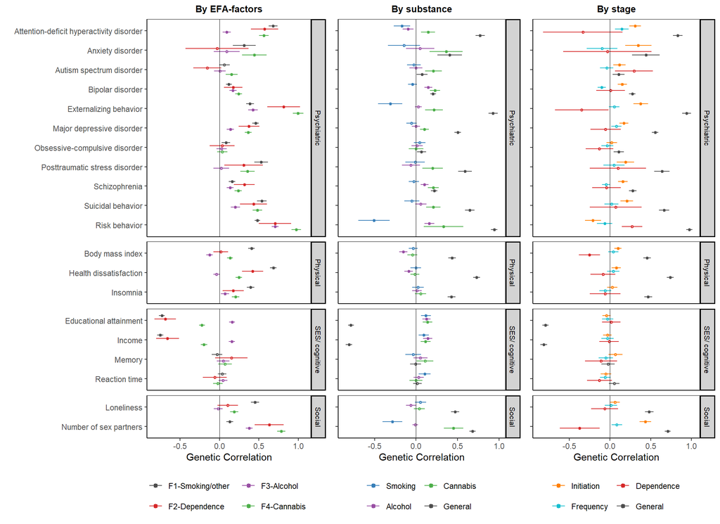

```r
plt_efa_b <- plt_efa +
  theme(legend.position = "bottom") +
  guides(color = guide_legend(nrow = 2))

plt_trait_b <- plt_trait +
  theme(legend.position = "bottom",
        axis.text.y = element_blank()) +
  guides(color = guide_legend(nrow = 2))

plt_sub_b <- plt_sub +
  theme(legend.position = "bottom",
        axis.text.y = element_blank()) +
  guides(color = guide_legend(nrow = 2))

ggarrange(plt_efa_b, plt_sub_b, plt_trait_b, nrow = 1, widths = c(0.85, 0.5, 0.5))
```

```r
ggsave("results/factor_rg/rg_all.svg", width = 11, height =8)
ggsave("results/factor_rg/rg_all.png", width = 11, height =8, dpi = 600)
```

## By trait type - comparing to model without G

In this version, I also add the estimate for trait ~~ factor without taking into account the overlap with G.

[figure not shown]

```r
INI <- readRDS("results/factor_rg/rg_ini.RDS") %>%
  filter(lhs != "G")
INI_orig <- readRDS("results/factor_rg/rg_adjusted_ini_withoutG.RDS") %>%
  filter(lhs != "G") %>%
  mutate(lhs = "INI_orig")

FRQ <- readRDS("results/factor_rg/rg_frq.RDS") %>%
  filter(lhs != "G")
FRQ_orig <- readRDS("results/factor_rg/rg_adjusted_frq_withoutG.RDS") %>%
  filter(lhs != "G") %>%
  mutate(lhs = "FRQ_orig")

DEP <- readRDS("results/factor_rg/rg_dep.RDS") %>%
  filter(lhs != "G")
DEP_orig <- readRDS("results/factor_rg/rg_adjusted_dep_withoutG.RDS") %>%
  filter(lhs != "G") %>%
  mutate(lhs = "DEP_orig")

G <- readRDS("results/factor_rg/rg_adjusted_gbytrait.RDS")

res <- rbind(INI, INI_orig, FRQ, FRQ_orig, DEP, DEP_orig, G)

# Combine and add the labels

labels <- fread("scripts/labels.csv")

res <- res %>%
  mutate(p_value = ifelse(p_value == "< 5e-300", 5e-300, p_value)) %>%
  mutate(p_value = as.numeric(p_value)) %>%
  full_join(labels, by = c("rhs" = "short")) %>%
  mutate(Category = fct_relevel(Category, "Psychiatric", "Physical", "SES/ cognitive", "Social"))

res <- res %>%
  select(lhs, label, STD_Genotype, STD_Genotype_SE, p_value, Category) %>%
  rename(rg = STD_Genotype, SE = STD_Genotype_SE) %>%
  mutate(lhs = fct_relevel(lhs, "INI", "INI_orig", "FRQ", "FRQ_orig", "DEP", "DEP_orig", "G")) %>%
  mutate(lhs = recode(lhs, "INI" = "Initiation", "INI_orig" = "Initation original", "FRQ" = "Frequency", "FRQ_orig" = "Frequency original", "DEP" = "Dependence", "DEP_orig"= "Dependence original", "
                      G" = "General"))

# Correct for multiple testing

res <- res %>%
  mutate(p_bin = ifelse((rg < 0 & rg + 1.96 * as.numeric(SE) < 0) | (rg > 0 & rg - 1.96 * as.numeric(SE) > 0) , "*", "")) %>%
  group_by(lhs) %>%
  mutate(p_fdr = p.adjust(as.numeric(p_value), "BH")) %>%
  ungroup() %>%
  mutate(p_fdr_bin = ifelse(p_fdr < 0.05, "sig", "nonsig")) %>%
  mutate(p_fdr_bin = as_factor(p_fdr_bin))

# Order by correlation with G

res <- res %>%
  mutate(rg_G = ifelse(lhs == "General", rg, NA)) %>%
  arrange(desc(rg_G)) %>%
  mutate(label = factor(label, levels = unique(label)))

# Plot

plt_trait <- ggplot(res, aes(x = rg, y = fct_rev(label), color = lhs, shape = p_fdr_bin, fill = p_fdr_bin)) +
  geom_pointrange(aes(xmin = rg - 1.96 * as.numeric(SE), xmax = rg + 1.96 * as.numeric(SE)),
                  position = position_dodge(width = -0.75),
                  size = 0.3, fatten = 2) +
  facet_grid(Category ~ ., scales = "free", space = "free_y") +
  geom_vline(xintercept = 0, size = 0.15) +
  theme_classic() +
  theme(axis.title.y = element_blank(),
        axis.title.x = element_text(size = 13),
        axis.text = element_text(size = 13),
        strip.text = element_text(colour = 'black', size = 13),
        strip.background = element_rect(fill = "lightgrey", color = "black"),
        panel.border = element_rect(color = "black", fill = NA),
        plot.title = element_text(size = 13, face = "bold", hjust = 0.5),
        legend.text = element_text(size = 13)
  ) +
  scale_colour_manual(values = c("#FF7F00", "#FFBE80", "#17BECF", "#94E5F0", "#D62728", "#F28A8A", "grey30"), name = NULL) +
  scale_shape_manual(values = c(19, 21)) +
  scale_fill_manual(values = c(NA, "white")) +
  xlab("Genetic Correlation") +
  guides(shape = "none", fill = "none") +
  ggtitle("By stage")

plt_trait
```

```r
ggsave("results/factor_rg/rg_trait_withoutG.svg", plt_trait, width = 9, height = 16)
```

## By substance - comparing to model without G

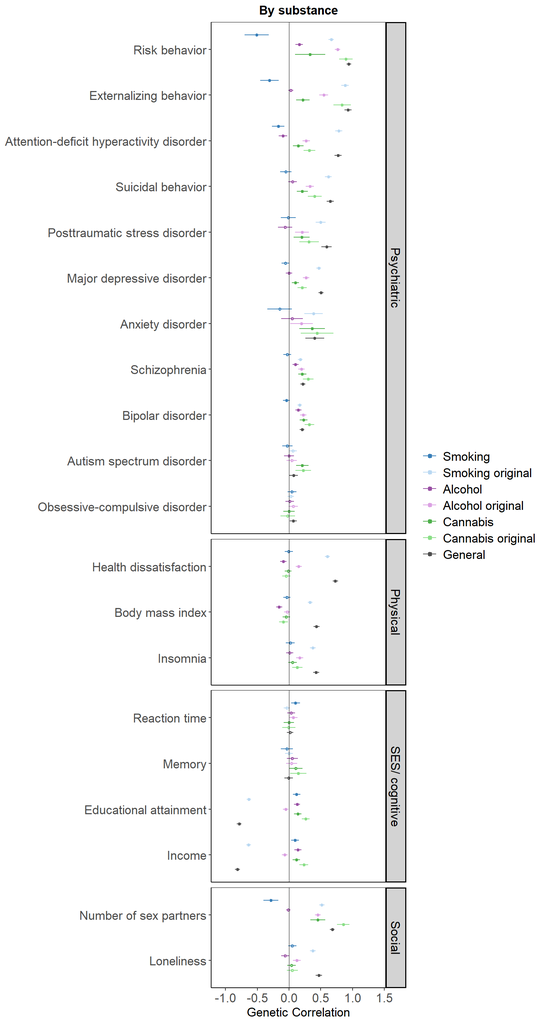

```r
SMK <- readRDS("results/factor_rg/rg_smk.RDS") %>%
  filter(lhs != "G")
SMK_orig <- readRDS("results/factor_rg/rg_smk_withoutG.RDS") %>%
  filter(lhs != "G") %>%
  mutate(lhs = "SMK_orig")

ALC <- readRDS("results/factor_rg/rg_alc.RDS") %>%
  filter(lhs != "G")
ALC_orig <- readRDS("results/factor_rg/rg_alc_withoutG.RDS") %>%
  filter(lhs != "G") %>%
  mutate(lhs = "ALC_orig")

CAN <- readRDS("results/factor_rg/rg_can.RDS") %>%
  filter(lhs != "G")
CAN_orig <- readRDS("results/factor_rg/rg_can_withoutG.RDS") %>%
  filter(lhs != "G") %>%
  mutate(lhs = "CAN_orig")

G <- readRDS("results/factor_rg/rg_gbysub.RDS")

res <- rbind(SMK, SMK_orig, ALC, ALC_orig, CAN, CAN_orig, G)

# Combine and add the labels

labels <- fread("scripts/labels.csv")

res <- res %>%
  mutate(p_value = ifelse(p_value == "< 5e-300", 5e-300, p_value)) %>%
  mutate(p_value = as.numeric(p_value)) %>%
  full_join(labels, by = c("rhs" = "short")) %>%
  mutate(Category = fct_relevel(Category, "Psychiatric", "Physical", "SES/ cognitive", "Social"))

# To add difference scores, pivot the table to wide format and back

res <- res %>%
  select(lhs, label, STD_Genotype, STD_Genotype_SE, p_value, Category) %>%
  rename(rg = STD_Genotype, SE = STD_Genotype_SE) %>%
  mutate(lhs = fct_relevel(lhs, "SMK", "SMK_orig", "ALC", "ALC_orig", "CAN", "CAN_orig", "G")) %>%
  mutate(lhs = recode(lhs, "SMK" = "Smoking", "SMK_orig" = "Smoking original", "ALC" = "Alcohol", "ALC_orig" = "Alcohol original", "CAN" = "Cannabis", "CAN_orig"= "Cannabis original", "G" = "General"))

# Correct for multiple testing

res <- res %>%
  mutate(p_bin = ifelse((rg < 0 & rg + 1.96 * as.numeric(SE) < 0) | (rg > 0 & rg - 1.96 * as.numeric(SE) > 0) , "*", "")) %>%
  group_by(lhs) %>%
  mutate(p_fdr = p.adjust(as.numeric(p_value), "BH")) %>%
  ungroup() %>%
  mutate(p_fdr_bin = ifelse(p_fdr < 0.05, "sig", "nonsig")) %>%
  mutate(p_fdr_bin = as_factor(p_fdr_bin))

# Order by correlation with G

res <- res %>%
  mutate(rg_G = ifelse(lhs == "General", rg, NA)) %>%
  arrange(desc(rg_G)) %>%
  mutate(label = factor(label, levels = unique(label)))

# Plot

plt_sub <- ggplot(res, aes(x = rg, y = fct_rev(label), color = lhs, shape = p_fdr_bin, fill = p_fdr_bin)) +
  geom_pointrange(aes(xmin = rg - 1.96 * as.numeric(SE), xmax = rg + 1.96 * as.numeric(SE)),
                  position = position_dodge(width = -0.75),
                  size = 0.3, fatten = 2) +
  facet_grid(Category ~ ., scales = "free", space = "free_y") +
  coord_cartesian(xlim = c(-1.1, 1.4)) +
  geom_vline(xintercept = 0, size = 0.15) +
  theme(axis.title.y = element_blank()) +
  theme_classic() +
  theme(axis.title.y = element_blank(),
        axis.title.x = element_text(size = 13),
        axis.text = element_text(size = 13),
        strip.text = element_text(colour = 'black', size = 13),
        strip.background = element_rect(fill = "lightgrey", color = "black"),
        panel.border = element_rect(color = "black", fill = NA),
        plot.title = element_text(size = 13, face = "bold", hjust = 0.5),
        legend.text = element_text(size = 13)
  ) +
  scale_colour_manual(values = c("#377EB8", "#B9D8F2", "#984EA3", "#dba1e3", "#4DAF4A", "#8ade87", "grey30"), name = NULL) +
  scale_shape_manual(values = c(19, 21)) +
  scale_fill_manual(values = c(NA, "white")) +
  xlab("Genetic Correlation") +
  guides(shape = "none", fill = "none") +
  ggtitle("By substance")

plt_sub
```

```r
ggsave("results/factor_rg/rg_sub_withoutG.svg", plt_sub, width = 9, height = 16)
```